# Credit Card Users Churn Prediction

## Description

### Background & Context

The Thera bank recently saw a steep decline in the number of users of their credit card, credit cards are a good source of income for banks because of different kinds of fees charged by the banks like annual fees, balance transfer fees, and cash advance fees, late payment fees, foreign transaction fees, and others. Some fees are charged to every user irrespective of usage, while others are charged under specified circumstances.

Customers’ leaving credit cards services would lead bank to loss, so the bank wants to analyze the data of customers and identify the customers who will leave their credit card services and reason for same – so that bank could improve upon those areas

You as a Data scientist at Thera bank need to come up with a classification model that will help the bank improve its services so that customers do not renounce their credit cards

You need to identify the best possible model that will give the required performance

### Objective

- Explore and visualize the dataset.
- Build a classification model to predict if the customer is going to churn or not
- Optimize the model using appropriate techniques
- Generate a set of insights and recommendations that will help the bank

### Data Dictionary:

- CLIENTNUM: Client number. Unique identifier for the customer holding the account
- Attrition_Flag: Internal event (customer activity) variable - if the account is closed then "Attrited Customer" else "Existing Customer"
- Customer_Age: Age in Years
- Gender: Gender of the account holder
- Dependent_count: Number of dependents
- Education_Level: Educational Qualification of the account holder - Graduate, High School, Unknown, Uneducated, College(refers to a college student), Post-Graduate, Doctorate.
- Marital_Status: Marital Status of the account holder
- Income_Category: Annual Income Category of the account holder
- Card_Category: Type of Card
- Months_on_book: Period of relationship with the bank
- Total_Relationship_Count: Total no. of products held by the customer
- Months_Inactive_12_mon: No. of months inactive in the last 12 months
- Contacts_Count_12_mon: No. of Contacts between the customer and bank in the last 12 months
- Credit_Limit: Credit Limit on the Credit Card
- Total_Revolving_Bal: The balance that carries over from one month to the next is the revolving balance
- Avg_Open_To_Buy: Open to Buy refers to the amount left on the credit card to use (Average of last 12 months)
- Total_Trans_Amt: Total Transaction Amount (Last 12 months)
- Total_Trans_Ct: Total Transaction Count (Last 12 months)
- Total_Ct_Chng_Q4_Q1: Ratio of the total transaction count in 4th quarter and the total transaction count in 1st quarter
- Total_Amt_Chng_Q4_Q1: Ratio of the total transaction amount in 4th quarter and the total transaction amount in 1st quarter
- Avg_Utilization_Ratio: Represents how much of the available credit the customer spent

### Import the necessary packages

```python
!pip install imblearn --user

!pip install imbalanced-learn --user

!pip install xgboost
```

```python
# to work with dataframes
import pandas as pd
import numpy as np


# libaries to help with data visualization
import matplotlib.pyplot as plt
import seaborn as sns

# To define maximum number of columns to be displayed in a dataframe
pd.set_option("display.max_columns", None)

# To supress scientific notations for a dataframe
pd.set_option("display.float_format", lambda x: "%.3f" % x)


# To impute missing values
from sklearn.impute import KNNImputer
# To impute missing values
from sklearn.impute import SimpleImputer

# to split data into train and test
from sklearn.model_selection import train_test_split, StratifiedKFold, cross_val_score
from sklearn.compose import ColumnTransformer
# To be used for data scaling and one hot encoding
from sklearn.preprocessing import StandardScaler, MinMaxScaler, OneHotEncoder
# to build logistic regression model
from sklearn.linear_model import LogisticRegression

# to create k folds of data and get cross validation score
from sklearn.model_selection import KFold
from sklearn.model_selection import cross_val_score

# to create pipeline and make_pipeline
from sklearn.pipeline import Pipeline, make_pipeline
from sklearn.tree import DecisionTreeClassifier
# to use standard scaler
from sklearn.preprocessing import StandardScaler
import matplotlib.pyplot as plt

from sklearn.ensemble import AdaBoostClassifier, GradientBoostingClassifier, RandomForestClassifier, BaggingClassifier

from xgboost import XGBClassifier



# To tune a model
from sklearn.model_selection import GridSearchCV
from sklearn.model_selection import RandomizedSearchCV

# To get different performance metrics
import sklearn.metrics as metrics
from sklearn.metrics import (
    classification_report,
    confusion_matrix,
    recall_score,
    accuracy_score,
    precision_score,
    f1_score,
)

# To undersample and oversample the data
from imblearn.over_sampling import SMOTE
from imblearn.under_sampling import RandomUnderSampler
import seaborn as sns
# To suppress warnings
import warnings
warnings.filterwarnings("ignore")
```

### Read the dataset

```python
from google.colab import drive
drive.mount('/content/drive')
```

```python
originaldata = pd.read_csv("/content/drive/MyDrive/Colab Notebooks/Feature Selection_Model Selection and Tuning/Project 5/BankChurners.csv")
```

```python
# copying data to another varaible to avoid any changes to original data
ccardDf = originaldata.copy()
```

### View the first and last 5 rows of the dataset.

```python
ccardDf.head()
```

|  | CLIENTNUM | Attrition_Flag | Customer_Age | Gender | Dependent_count | Education_Level | Marital_Status | Income_Category | Card_Category | Months_on_book | Total_Relationship_Count | Months_Inactive_12_mon | Contacts_Count_12_mon | Credit_Limit | Total_Revolving_Bal | Avg_Open_To_Buy | Total_Amt_Chng_Q4_Q1 | Total_Trans_Amt | Total_Trans_Ct | Total_Ct_Chng_Q4_Q1 | Avg_Utilization_Ratio |
| --- | --- | --- | --- | --- | --- | --- | --- | --- | --- | --- | --- | --- | --- | --- | --- | --- | --- | --- | --- | --- | --- |
| 0 | 768805383 | Existing Customer | 45 | M | 3 | High School | Married | $60K - $80K | Blue | 39 | 5 | 1 | 3 | 12691.000 | 777 | 11914.000 | 1.335 | 1144 | 42 | 1.625 | 0.061 |
| 1 | 818770008 | Existing Customer | 49 | F | 5 | Graduate | Single | Less than $40K | Blue | 44 | 6 | 1 | 2 | 8256.000 | 864 | 7392.000 | 1.541 | 1291 | 33 | 3.714 | 0.105 |
| 2 | 713982108 | Existing Customer | 51 | M | 3 | Graduate | Married | $80K - $120K | Blue | 36 | 4 | 1 | 0 | 3418.000 | 0 | 3418.000 | 2.594 | 1887 | 20 | 2.333 | 0.000 |
| 3 | 769911858 | Existing Customer | 40 | F | 4 | High School | NaN | Less than $40K | Blue | 34 | 3 | 4 | 1 | 3313.000 | 2517 | 796.000 | 1.405 | 1171 | 20 | 2.333 | 0.760 |
| 4 | 709106358 | Existing Customer | 40 | M | 3 | Uneducated | Married | $60K - $80K | Blue | 21 | 5 | 1 | 0 | 4716.000 | 0 | 4716.000 | 2.175 | 816 | 28 | 2.500 | 0.000 |

```python
ccardDf.tail()
```

|  | CLIENTNUM | Attrition_Flag | Customer_Age | Gender | Dependent_count | Education_Level | Marital_Status | Income_Category | Card_Category | Months_on_book | Total_Relationship_Count | Months_Inactive_12_mon | Contacts_Count_12_mon | Credit_Limit | Total_Revolving_Bal | Avg_Open_To_Buy | Total_Amt_Chng_Q4_Q1 | Total_Trans_Amt | Total_Trans_Ct | Total_Ct_Chng_Q4_Q1 | Avg_Utilization_Ratio |
| --- | --- | --- | --- | --- | --- | --- | --- | --- | --- | --- | --- | --- | --- | --- | --- | --- | --- | --- | --- | --- | --- |
| 10122 | 772366833 | Existing Customer | 50 | M | 2 | Graduate | Single | $40K - $60K | Blue | 40 | 3 | 2 | 3 | 4003.000 | 1851 | 2152.000 | 0.703 | 15476 | 117 | 0.857 | 0.462 |
| 10123 | 710638233 | Attrited Customer | 41 | M | 2 | NaN | Divorced | $40K - $60K | Blue | 25 | 4 | 2 | 3 | 4277.000 | 2186 | 2091.000 | 0.804 | 8764 | 69 | 0.683 | 0.511 |
| 10124 | 716506083 | Attrited Customer | 44 | F | 1 | High School | Married | Less than $40K | Blue | 36 | 5 | 3 | 4 | 5409.000 | 0 | 5409.000 | 0.819 | 10291 | 60 | 0.818 | 0.000 |
| 10125 | 717406983 | Attrited Customer | 30 | M | 2 | Graduate | NaN | $40K - $60K | Blue | 36 | 4 | 3 | 3 | 5281.000 | 0 | 5281.000 | 0.535 | 8395 | 62 | 0.722 | 0.000 |
| 10126 | 714337233 | Attrited Customer | 43 | F | 2 | Graduate | Married | Less than $40K | Silver | 25 | 6 | 2 | 4 | 10388.000 | 1961 | 8427.000 | 0.703 | 10294 | 61 | 0.649 | 0.189 |

### Understand the shape of the dataset.

```python
ccardDf.shape
```

```
(10127, 21)
```

- Dataset has 10127 rows and 21 columns.

### Check the data types of the columns for the dataset.

```python
ccardDf.info()
```

```
<class 'pandas.core.frame.DataFrame'>
RangeIndex: 10127 entries, 0 to 10126
Data columns (total 21 columns):
 #   Column                    Non-Null Count  Dtype
---  ------                    --------------  -----
 0   CLIENTNUM                 10127 non-null  int64
 1   Attrition_Flag            10127 non-null  object
 2   Customer_Age              10127 non-null  int64
 3   Gender                    10127 non-null  object
 4   Dependent_count           10127 non-null  int64
 5   Education_Level           8608 non-null   object
 6   Marital_Status            9378 non-null   object
 7   Income_Category           10127 non-null  object
 8   Card_Category             10127 non-null  object
 9   Months_on_book            10127 non-null  int64
 10  Total_Relationship_Count  10127 non-null  int64
 11  Months_Inactive_12_mon    10127 non-null  int64
 12  Contacts_Count_12_mon     10127 non-null  int64
 13  Credit_Limit              10127 non-null  float64
 14  Total_Revolving_Bal       10127 non-null  int64
 15  Avg_Open_To_Buy           10127 non-null  float64
 16  Total_Amt_Chng_Q4_Q1      10127 non-null  float64
 17  Total_Trans_Amt           10127 non-null  int64
 18  Total_Trans_Ct            10127 non-null  int64
 19  Total_Ct_Chng_Q4_Q1       10127 non-null  float64
 20  Avg_Utilization_Ratio     10127 non-null  float64
dtypes: float64(5), int64(10), object(6)
memory usage: 1.6+ MB
```

```python
result = ccardDf.select_dtypes(include=np.int64).columns.tolist()
# print(result)
print("These columns {} are of type int64".format(result))
```

```
These columns ['CLIENTNUM', 'Customer_Age', 'Dependent_count', 'Months_on_book', 'Total_Relationship_Count', 'Months_Inactive_12_mon', 'Contacts_Count_12_mon', 'Total_Revolving_Bal', 'Total_Trans_Amt', 'Total_Trans_Ct'] are of type int64
```

```python
result = ccardDf.select_dtypes(include=np.float64).columns.tolist()
# print(result)
print("These columns {} are of type float64".format(result))
```

```
These columns ['Credit_Limit', 'Avg_Open_To_Buy', 'Total_Amt_Chng_Q4_Q1', 'Total_Ct_Chng_Q4_Q1', 'Avg_Utilization_Ratio'] are of type float64
```

```python
result = ccardDf.select_dtypes(include=np.object_).columns.tolist()
# print(result)
print("These columns {} are of type object".format(result))
```

```
These columns ['Attrition_Flag', 'Gender', 'Education_Level', 'Marital_Status', 'Income_Category', 'Card_Category'] are of type object
```

## Initial Data Analysis and Data Pre-Processing

### Check for missing values and duplicates

```python
ccardDf.isnull().sum()
```

```
CLIENTNUM                      0
Attrition_Flag                 0
Customer_Age                   0
Gender                         0
Dependent_count                0
Education_Level             1519
Marital_Status               749
Income_Category                0
Card_Category                  0
Months_on_book                 0
Total_Relationship_Count       0
Months_Inactive_12_mon         0
Contacts_Count_12_mon          0
Credit_Limit                   0
Total_Revolving_Bal            0
Avg_Open_To_Buy                0
Total_Amt_Chng_Q4_Q1           0
Total_Trans_Amt                0
Total_Trans_Ct                 0
Total_Ct_Chng_Q4_Q1            0
Avg_Utilization_Ratio          0
dtype: int64
```

`Education_Level` and `Marital_Status` fields have missing values, we should impute them after splitting the data to avoid data leakage.

```python
ccardDf.duplicated().any()
```

```
False
```

By observing the top and last 5 records in this dataset CLIENTNUM column looks like a unique identifier for the customer data which may not be significant for our analysis, so we can drop this column.

```python
# we do not need the ID column here, since it is not related to any of the columns, so this can be dropped
ccardDf.drop("CLIENTNUM", axis=1, inplace=True)
```

### Statistical summary of Numerical columns

```python
# summary of numerical attributes
ccardDf.select_dtypes(include= np.number).describe().T
```

|  | count | mean | std | min | 25% | 50% | 75% | max |
| --- | --- | --- | --- | --- | --- | --- | --- | --- |
| Customer_Age | 10127.000 | 46.326 | 8.017 | 26.000 | 41.000 | 46.000 | 52.000 | 73.000 |
| Dependent_count | 10127.000 | 2.346 | 1.299 | 0.000 | 1.000 | 2.000 | 3.000 | 5.000 |
| Months_on_book | 10127.000 | 35.928 | 7.986 | 13.000 | 31.000 | 36.000 | 40.000 | 56.000 |
| Total_Relationship_Count | 10127.000 | 3.813 | 1.554 | 1.000 | 3.000 | 4.000 | 5.000 | 6.000 |
| Months_Inactive_12_mon | 10127.000 | 2.341 | 1.011 | 0.000 | 2.000 | 2.000 | 3.000 | 6.000 |
| Contacts_Count_12_mon | 10127.000 | 2.455 | 1.106 | 0.000 | 2.000 | 2.000 | 3.000 | 6.000 |
| Credit_Limit | 10127.000 | 8631.954 | 9088.777 | 1438.300 | 2555.000 | 4549.000 | 11067.500 | 34516.000 |
| Total_Revolving_Bal | 10127.000 | 1162.814 | 814.987 | 0.000 | 359.000 | 1276.000 | 1784.000 | 2517.000 |
| Avg_Open_To_Buy | 10127.000 | 7469.140 | 9090.685 | 3.000 | 1324.500 | 3474.000 | 9859.000 | 34516.000 |
| Total_Amt_Chng_Q4_Q1 | 10127.000 | 0.760 | 0.219 | 0.000 | 0.631 | 0.736 | 0.859 | 3.397 |
| Total_Trans_Amt | 10127.000 | 4404.086 | 3397.129 | 510.000 | 2155.500 | 3899.000 | 4741.000 | 18484.000 |
| Total_Trans_Ct | 10127.000 | 64.859 | 23.473 | 10.000 | 45.000 | 67.000 | 81.000 | 139.000 |
| Total_Ct_Chng_Q4_Q1 | 10127.000 | 0.712 | 0.238 | 0.000 | 0.582 | 0.702 | 0.818 | 3.714 |
| Avg_Utilization_Ratio | 10127.000 | 0.275 | 0.276 | 0.000 | 0.023 | 0.176 | 0.503 | 0.999 |

**Observations**

- *Attrition_Flag* is qualitative, (Existing Customer - can be classified as 0 for not Attired and Attired Customer = 1 if they have attired).
- *Customer_Age* is quantitative, minimum age is 26, max age is 73 and median age is 46 years.
- *Dependent_count* is quantitative, it can be considered as categorical too, I am considering it as a quantitative field, minimum number of deendents as 0 and maximum number of dependents as 5.
- *'Months_on_book', 'Total_Relationship_Count', 'Months_Inactive_12_mon', 'Contacts_Count_12_mon', 'Total_Revolving_Bal', 'Total_Trans_Amt', 'Total_Trans_Ct'* are all quantitative values having the mean, min and max values for each listed in the above table.

### Statistical summary of categorical columns

```python
# summary of numerical attributes
ccardDf.select_dtypes(include = 'object').describe().T
```

|  | count | unique | top | freq |
| --- | --- | --- | --- | --- |
| Attrition_Flag | 10127 | 2 | Existing Customer | 8500 |
| Gender | 10127 | 2 | F | 5358 |
| Education_Level | 8608 | 6 | Graduate | 3128 |
| Marital_Status | 9378 | 3 | Married | 4687 |
| Income_Category | 10127 | 6 | Less than $40K | 3561 |
| Card_Category | 10127 | 4 | Blue | 9436 |

```python
# list of all categorical variables
cat_cols = ccardDf.select_dtypes(include = 'object')

# printing the number of occurrences of each unique value in each categorical column
for column in cat_cols:
    print(ccardDf[column].value_counts())
    print("-" * 40)
```

```
Existing Customer    8500
Attrited Customer    1627
Name: Attrition_Flag, dtype: int64
----------------------------------------
F    5358
M    4769
Name: Gender, dtype: int64
----------------------------------------
Graduate         3128
High School      2013
Uneducated       1487
College          1013
Post-Graduate     516
Doctorate         451
Name: Education_Level, dtype: int64
----------------------------------------
Married     4687
Single      3943
Divorced     748
Name: Marital_Status, dtype: int64
----------------------------------------
Less than $40K    3561
$40K - $60K       1790
$80K - $120K      1535
$60K - $80K       1402
abc               1112
$120K +            727
Name: Income_Category, dtype: int64
----------------------------------------
Blue        9436
Silver       555
Gold         116
Platinum      20
Name: Card_Category, dtype: int64
----------------------------------------
```

**Observations:**

- `Attrition_Flag` data shows that most of the customers are Existing Customers, very few of them are Attired Customers.
- `Gender` column data shows that there are more Female customers then Male customers.
- Different type of categories in the `Education Level` column are:
  1. Graduate
  2. High School
  3. Uneducated
  4. College
  5. Post-Graduate
  6. Doctorate

     > Most of them have Graduate degree.
- `Marital_Status`, there are 3 types of Marital status:
  1. Married
  2. Single
  3. Divorced

     > Most of the customers are Married
- `Income_Category` following are the different Income categories:
  1. Less than $40K
  2. $40K - $60K
  3. $80K - $120K
  4. $60K - $80K
  5. abc
  6. $120K +

     > Most of them have income of Less than $40K. There is a category called **"abc"**, it, looking at the salary ranges it appears that all the different possible combination of categories are listed. We can replace abc will nan and treat it as a missing value later on.
- Different types of `Card_Category` are:
  1. Blue
  2. Silver
  3. Gold
  4. Platinum

     > Most of the customers have Blue card.

### Check the balance of class on Target variable

Since our goal is to build a classification model to predict if the customer is going to churn or not, we will replace the Attrition_Flag value of 'Existing Customer' with 0 (meaning not attired) and value of 'Attrited Customer' with 1 (already attired).

```python
## Replace Attrited and Existing customers to 1 and 0 respectively, for analysis.
ccardDf["Attrition_Flag"].replace("Attrited Customer", 1, inplace=True)
ccardDf["Attrition_Flag"].replace("Existing Customer", 0, inplace=True)
```

```python
# Checking the distribution of target variable
display(ccardDf['Attrition_Flag'].value_counts(), ccardDf['Attrition_Flag'].value_counts(normalize = True)*100)
```

```
0    8500
1    1627
Name: Attrition_Flag, dtype: int64
```

```
0   83.934
1   16.066
Name: Attrition_Flag, dtype: float64
```

~84% of customers have not Attrited, while ~16% of them have Attrited.

- This indicates that the data is imbalanced between both the classes.

# Exploratory Data Analysis

## Univariate Analysis

#### Functions for creating graphs and charts

```python
# While doing uni-variate analysis of numerical variables we want to study their central tendency
# and dispersion.
# Let us write a function that will help us create boxplot and histogram for any input numerical
# variable.
# This function takes the numerical column as the input and returns the boxplots
# and histograms for the variable.
# Let us see if this help us write faster and cleaner code.
# function to plot a boxplot and a histogram along the same scale.
def histogram_boxplot(data, feature, figsize=(12, 7), kde=False, bins=None):
    """
    Boxplot and histogram combined

    data: dataframe
    feature: dataframe column
    figsize: size of figure (default (12,7))
    kde: whether to show the density curve (default False)
    bins: number of bins for histogram (default None)
    """
    f2, (ax_box2, ax_hist2) = plt.subplots(
        nrows=2,  # Number of rows of the subplot grid= 2
        sharex=True,  # x-axis will be shared among all subplots
        gridspec_kw={"height_ratios": (0.25, 0.75)},
        figsize=figsize,
    )  # creating the 2 subplots
    sns.boxplot(
        data=data, x=feature, ax=ax_box2, showmeans=True, color="violet"
    )  # boxplot will be created and a star will indicate the mean value of the column
    sns.histplot(
        data=data, x=feature, kde=kde, ax=ax_hist2, bins=bins, palette="winter"
    ) if bins else sns.histplot(
        data=data, x=feature, kde=kde, ax=ax_hist2
    )  # For histogram
    ax_hist2.axvline(
        data[feature].mean(), color="green", linestyle="--"
    )  # Add mean to the histogram
    ax_hist2.axvline(
        data[feature].median(), color="black", linestyle="-"
    )  # Add median to the histogram
```

```python
# function to create labeled barplots

def labeled_barplot(data, feature, perc=False, n=None):
    """
    Barplot with percentage at the top

    data: dataframe
    feature: dataframe column
    perc: whether to display percentages instead of count (default is False)
    n: displays the top n category levels (default is None, i.e., display all levels)
    """

    total = len(data[feature])  # length of the column
    count = data[feature].nunique()
    if n is None:
        plt.figure(figsize=(count + 1, 5))
    else:
        plt.figure(figsize=(n + 1, 5))

    plt.xticks(rotation=90, fontsize=15)
    ax = sns.countplot(
        data=data,
        x=feature,
        palette="Paired",
        order=data[feature].value_counts().index[:n].sort_values(),
    )

    for p in ax.patches:
        if perc == True:
            label = "{:.1f}%".format(
                100 * p.get_height() / total
            )  # percentage of each class of the category
        else:
            label = p.get_height()  # count of each level of the category

        x = p.get_x() + p.get_width() / 2  # width of the plot
        y = p.get_height()  # height of the plot

        ax.annotate(
            label,
            (x, y),
            ha="center",
            va="center",
            size=12,
            xytext=(0, 5),
            textcoords="offset points",
        )  # annotate the percentage

    plt.show()  # show the plot
```

#### Observations on Customer_Age

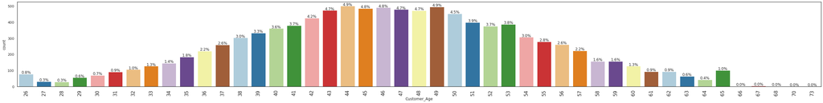

```python
labeled_barplot(ccardDf,'Customer_Age', perc=True)
```

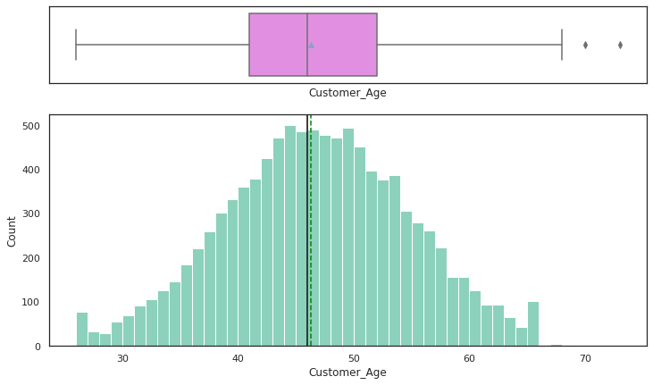

```python
histogram_boxplot(ccardDf, "Customer_Age")
```

**Customer_Age seem to be evenly distributed with the mean and median age of customers between 44 to 46 years**

### Observations on Months_on_book

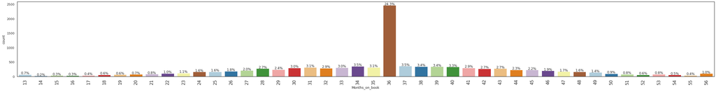

```python
labeled_barplot(ccardDf,'Months_on_book', perc=True)
```

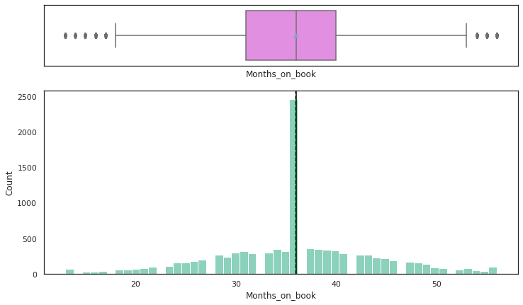

```python
histogram_boxplot(ccardDf,'Months_on_book')
```

- There are several outliers in `Months_on_book` field, there is a steady spike for 36 months, which may be considered as an outlier and possibly removed.

### Observations on Credit_Limit

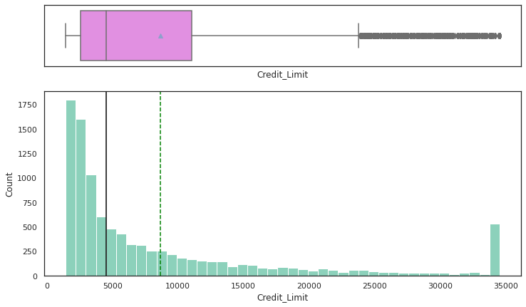

```python
histogram_boxplot(ccardDf,'Credit_Limit')
```

### Observations on Total_Revolving_Bal

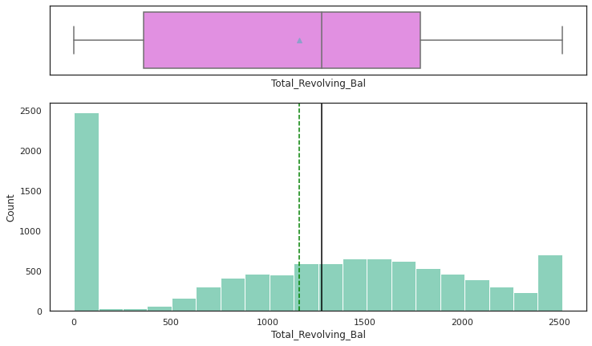

```python
histogram_boxplot(ccardDf,'Total_Revolving_Bal')
```

### Observations on Avg_Open_To_Buy

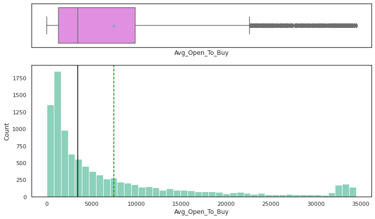

```python
histogram_boxplot(ccardDf, "Avg_Open_To_Buy")
```

- There are several outliers in this data and is right-skewed.
- This shows that most customers used most of their spending limit, while only a few customers left with a majority of their credit amount.

### Observations on Total_Trans_Ct

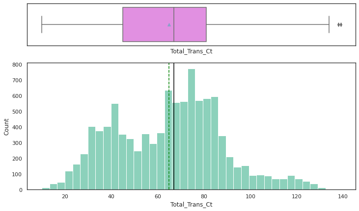

```python
histogram_boxplot(ccardDf, "Total_Trans_Ct")
```

- The distribution of Total_Trans_Ct is not evenly distributed, there are two peaks on 45 and 70 transactions.

### Observations on Total_Amt_Chng_Q4_Q1

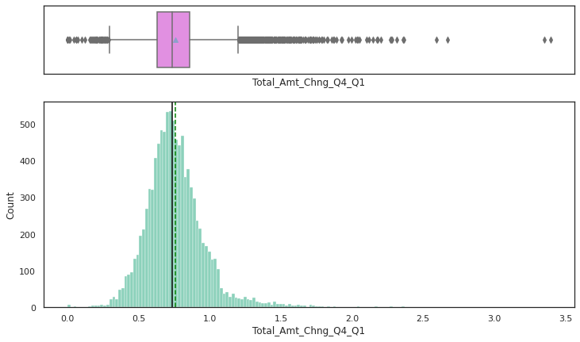

```python
histogram_boxplot(ccardDf, "Total_Amt_Chng_Q4_Q1")
```

- The data for Total_Amt_Chng_Q4_Q1 seems to be normally distributed but there's a slight skew towards the right.
- From the boxplot, we can see that there are outliers on both sides.

### Observations on Total_Trans_Amt

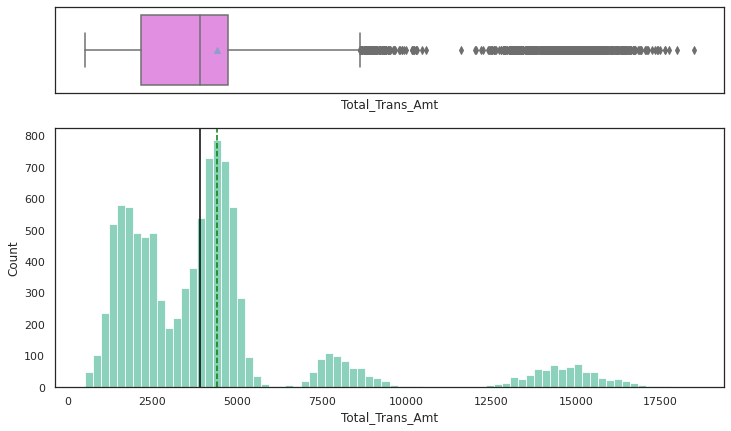

```python
histogram_boxplot(ccardDf, "Total_Trans_Amt")
```

### Observations on Total_Ct_Chng_Q4_Q1

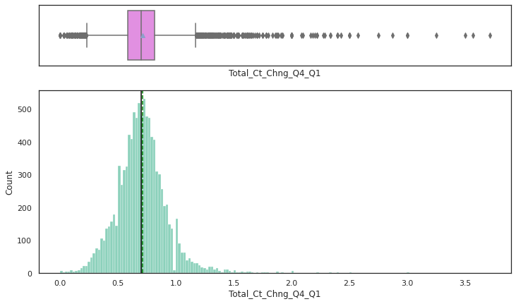

```python
histogram_boxplot(ccardDf, "Total_Ct_Chng_Q4_Q1")
```

- The distribution of Total_Ct_Chng_Q4_Q1 looks normally distributed but with a slight skew towards the right.
- From the boxplot, we can see that there are outliers on the right and a few on the left.

### Observations on Avg_Utilization_Ratio

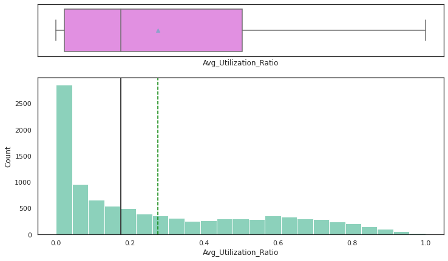

```python
histogram_boxplot(ccardDf, "Avg_Utilization_Ratio")
```

### Observations on Dependent_count

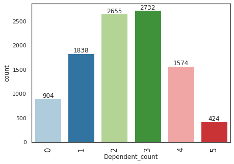

```python
labeled_barplot(ccardDf, "Dependent_count")
```

- Most customers having 2 or 3 dependents.

### Observations on Total_Relationship_Count

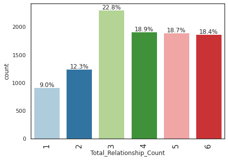

```python
labeled_barplot(ccardDf, "Total_Relationship_Count", perc=True)
```

### Observations on Months_Inactive_12_mon

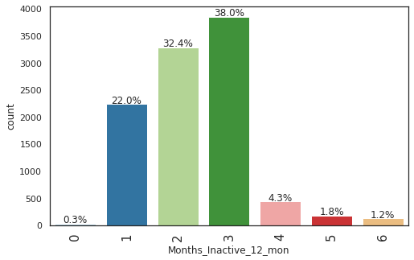

```python
labeled_barplot(ccardDf, "Months_Inactive_12_mon", perc=True)
```

- About 38% of customers were inactive for 3 months in the last 12 months
- About 32.4% of customers were inactive for 2 months in the last 12 months.
- Most of the customers were inactive for 1,2 or 3 months

### Observations on Contacts_Count_12_mon

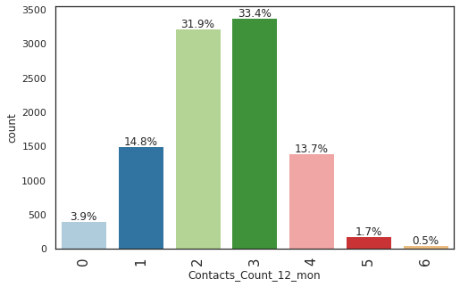

```python
labeled_barplot(ccardDf, "Contacts_Count_12_mon", perc=True)
```

- About 33.4% of customers were contacted 3 times in the last 12 months
- About 31.9% of customers were contacted twice in the last 12 months.
- About 13-14% of the customers were contacted once 4 times and once respectively.

### Observations on Gender

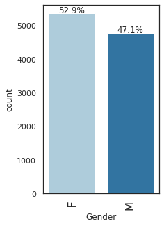

```python
labeled_barplot(ccardDf, "Gender", perc=True)
```

- There are slightly more Female customers than Male customers

### Observations on Education_Level

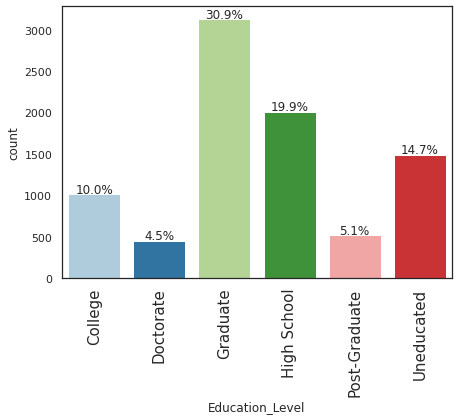

```python
labeled_barplot(ccardDf, "Education_Level", perc=True)
```

- 30.9% of the customers are graduates, followed by 19.9% of the customers who have completed high school.
- 14.7% of customers do not have any education.

### Observations on Marital_Status

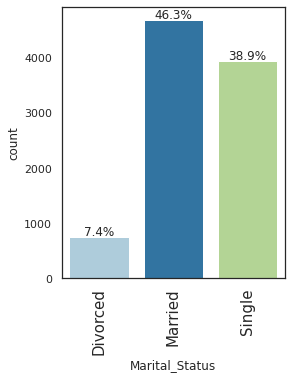

```python
labeled_barplot(ccardDf, "Marital_Status", perc=True)
```

- 46.3% of the customers are Married, where as 38.9% are Single.

### Observations on Income_Category

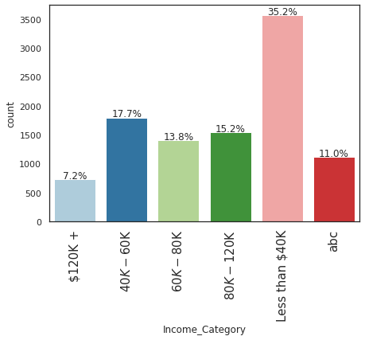

```python
labeled_barplot(ccardDf, "Income_Category", perc=True)
```

- 35.2% of the customers have the Less than 40k income
- 17.7% of the customers are in the 40k-60k income group.
- 11% of them do not belong to a reasonable category, this value has to be corrected.

### Observations on Card_Category

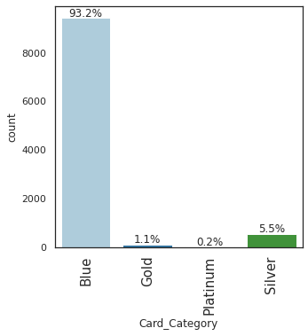

```python
labeled_barplot(ccardDf, "Card_Category", perc=True)
```

- Most of the customers about 93.2% have the Blue card.
- There are a few silver and gold, followed by platinum.

### Observations on Attrition_Flag

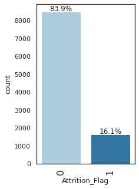

```python
labeled_barplot(ccardDf, "Attrition_Flag", perc=True)
```

- 16.1% of the customers attrited.
- This indicates an imbalance in the data.

## Bivariate and Multivariate Analysis

### Correlation Matrix

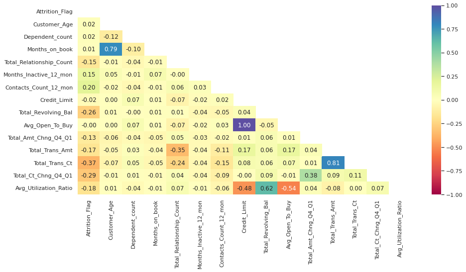

```python
plt.figure(figsize=(15, 7))
# sns.heatmap(tourismDf.corr(), annot=True, vmin=-1, vmax=1, fmt=".2f")
# plt.show()

corr= ccardDf.corr()

# Getting the Upper Triangle of the co-relation matrix
matrix = np.triu(corr)

# using the upper triangle matrix as mask
sns.heatmap(corr, annot=True,vmin=-1, vmax=1, fmt=".2f", mask=matrix, cmap='Spectral')
plt.show()
```

**Observations:**

**Since the data set here is small and the focus of this project is to build different models and compare them, I am choosing to keep all the fields and due to time constraint. Ideally we can drop some of the columns with negative correlation after proper analysis.**

```python
sns.set_palette(sns.color_palette("Set2", 8))
sns.pairplot(ccardDf, hue="Attrition_Flag",corner=False)
plt.show()
```

[output not shown]

```
Output hidden; open in https://colab.research.google.com to view.
```

- Let's explore this further with the help of other plots.

### Functions to plot charts

```python
### function to plot distributions wrt target
def distribution_plot_wrt_target(data, predictor, target):

    fig, axs = plt.subplots(2, 2, figsize=(12, 10))

    target_uniq = data[target].unique()

    axs[0, 0].set_title("Distribution of target for target=" + str(target_uniq[0]))
    sns.histplot(
        data=data[data[target] == target_uniq[0]],
        x=predictor,
        kde=True,
        ax=axs[0, 0],
        color="teal",
        stat="density",
    )

    axs[0, 1].set_title("Distribution of target for target=" + str(target_uniq[1]))
    sns.histplot(
        data=data[data[target] == target_uniq[1]],
        x=predictor,
        kde=True,
        ax=axs[0, 1],
        color="orange",
        stat="density",
    )

    axs[1, 0].set_title("Boxplot w.r.t target")
    sns.boxplot(data=data, x=target, y=predictor, ax=axs[1, 0], palette="gist_rainbow")

    axs[1, 1].set_title("Boxplot (without outliers) w.r.t target")
    sns.boxplot(
        data=data,
        x=target,
        y=predictor,
        ax=axs[1, 1],
        showfliers=False,
        palette="gist_rainbow",
    )

    plt.tight_layout()
    plt.show()
```

```python
# function to plot stacked bar chart
def stacked_barplot(data, predictor, target):
    """
    Print the category counts and plot a stacked bar chart

    data: dataframe
    predictor: independent variable
    target: target variable
    """
    count = data[predictor].nunique()
    sorter = data[target].value_counts().index[-1]
    tab1 = pd.crosstab(data[predictor], data[target], margins=True).sort_values(
        by=sorter, ascending=False
    )
    print(tab1)
    print("-" * 120)
    tab = pd.crosstab(data[predictor], data[target], normalize="index").sort_values(
        by=sorter, ascending=False
    )
    tab.plot(kind="bar", stacked=True, figsize=(count + 5, 6))
    plt.legend(
        loc="lower left", frameon=False,
    )
    plt.legend(loc="upper left", bbox_to_anchor=(1, 1))
    plt.show()
```

```python
### Function to plot distributions


def distribution_plot_wrt_target(data, predictor, target):

    fig, axs = plt.subplots(2, 2, figsize=(12, 10))

    target_uniq = data[target].unique()

    axs[0, 0].set_title("Distribution of target for target=" + str(target_uniq[0]))
    sns.histplot(
        data=data[data[target] == target_uniq[0]],
        x=predictor,
        kde=True,
        ax=axs[0, 0],
        color="teal",
    )

    axs[0, 1].set_title("Distribution of target for target=" + str(target_uniq[1]))
    sns.histplot(
        data=data[data[target] == target_uniq[1]],
        x=predictor,
        kde=True,
        ax=axs[0, 1],
        color="orange",
    )

    axs[1, 0].set_title("Boxplot w.r.t target")
    sns.boxplot(data=data, x=target, y=predictor, ax=axs[1, 0], palette="gist_rainbow")

    axs[1, 1].set_title("Boxplot (without outliers) w.r.t target")
    sns.boxplot(
        data=data,
        x=target,
        y=predictor,
        ax=axs[1, 1],
        showfliers=False,
        palette="gist_rainbow",
    )

    plt.tight_layout()
    plt.show()
```

### Attrition_Flag vs Gender

```
Attrition_Flag     0     1    All
Gender
All             8500  1627  10127
F               4428   930   5358
M               4072   697   4769
------------------------------------------------------------------------------------------------------------------------
```

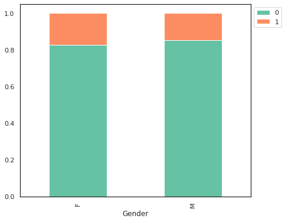

```python
stacked_barplot(ccardDf, "Gender", "Attrition_Flag")
```

- Marginal difference in attrition of Male Vs Femal customers

### Attrition_Flag vs Marital_Status

```
Attrition_Flag     0     1   All
Marital_Status
All             7880  1498  9378
Married         3978   709  4687
Single          3275   668  3943
Divorced         627   121   748
------------------------------------------------------------------------------------------------------------------------
```

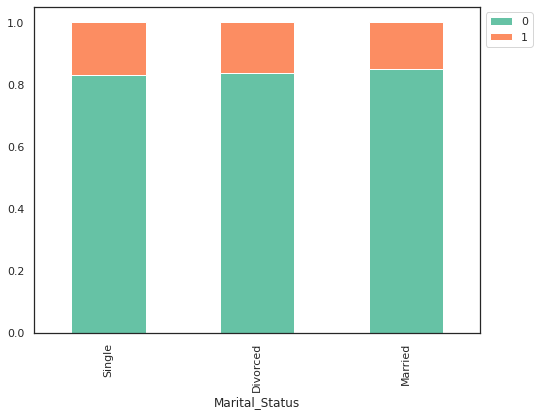

```python
stacked_barplot(ccardDf, "Marital_Status", "Attrition_Flag")
```

- Not much difference in attrition percentages for Marital_Status.

### Attrition_Flag vs Education_Level

```
Attrition_Flag      0     1   All
Education_Level
All              7237  1371  8608
Graduate         2641   487  3128
High School      1707   306  2013
Uneducated       1250   237  1487
College           859   154  1013
Doctorate         356    95   451
Post-Graduate     424    92   516
------------------------------------------------------------------------------------------------------------------------
```

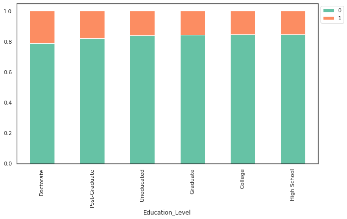

```python
stacked_barplot(ccardDf, "Education_Level", "Attrition_Flag")
```

- Customers with higher education - Doctorates and Post Graduates are the ones most(~20% for both education levels) attriting.

### Attrition_Flag vs Income_Category

```
Attrition_Flag      0     1    All
Income_Category
All              8500  1627  10127
Less than $40K   2949   612   3561
$40K - $60K      1519   271   1790
$80K - $120K     1293   242   1535
$60K - $80K      1213   189   1402
abc               925   187   1112
$120K +           601   126    727
------------------------------------------------------------------------------------------------------------------------
```

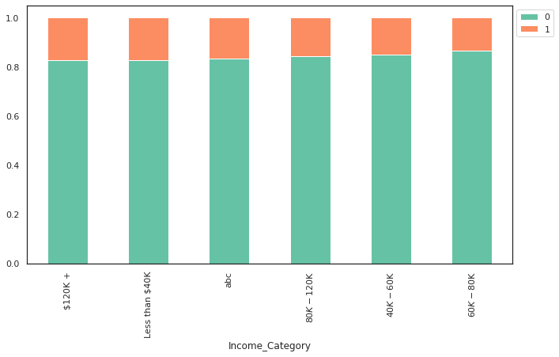

```python
stacked_barplot(ccardDf, "Income_Category", "Attrition_Flag")
```

- The customers from two extreme income groups - Earning less than 40K and Earning more than 120k+ are the ones attriting the most.

### Attrition_Flag vs Card_Category

```
Attrition_Flag     0     1    All
Card_Category
All             8500  1627  10127
Blue            7917  1519   9436
Silver           473    82    555
Gold              95    21    116
Platinum          15     5     20
------------------------------------------------------------------------------------------------------------------------
```

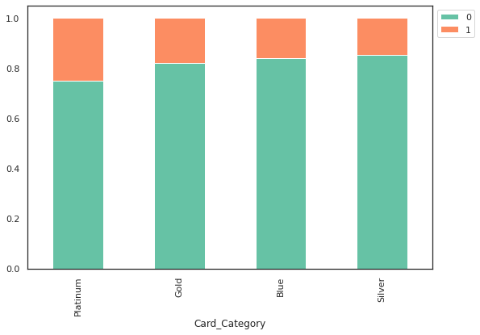

```python
stacked_barplot(ccardDf, "Card_Category", "Attrition_Flag")
```

### Attrition_Flag vs Contacts_Count_12_mon

```
Attrition_Flag            0     1    All
Contacts_Count_12_mon
All                    8500  1627  10127
3                      2699   681   3380
2                      2824   403   3227
4                      1077   315   1392
1                      1391   108   1499
5                       117    59    176
6                         0    54     54
0                       392     7    399
------------------------------------------------------------------------------------------------------------------------
```

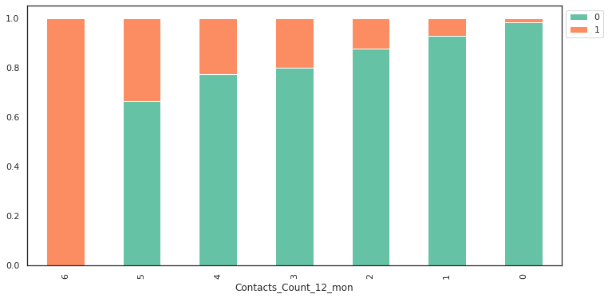

```python
stacked_barplot(ccardDf, "Contacts_Count_12_mon", "Attrition_Flag")
```

- Highest attrition is among the customers who interacted the most with the bank.
- It may possibly depict that bank is not able to resolve the problems faced by customers

### Attrition_Flag vs Months_Inactive_12_mon

```
Attrition_Flag             0     1    All
Months_Inactive_12_mon
All                     8500  1627  10127
3                       3020   826   3846
2                       2777   505   3282
4                        305   130    435
1                       2133   100   2233
5                        146    32    178
6                        105    19    124
0                         14    15     29
------------------------------------------------------------------------------------------------------------------------
```

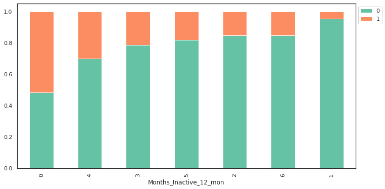

```python
stacked_barplot(ccardDf, "Months_Inactive_12_mon", "Attrition_Flag")
```